# rare-variants

Seongwon Hwang

18-09-2026

# Load packages and functions

```r
# Installed the following packages by running:
# > conda env create -f env.yml
# > conda activate rare-variants

suppressMessages(library(ggplot2))
# suppressMessages(library(MatchIt))
# suppressMessages(library(survival))

source("R/utils.R")
```

Individual-level UK Biobank files are not in this repository. After placing the files in `data/README.md`, the phenotype lists used by the analysis scripts can be built as follows.

```r
tv <- load_TV()
lactose <- load_lactose_intolerance()
```

# Match cases to controls

Cases were matched to controls on PC1 through PC5 using Mahalanobis distance, without replacement. Sex and genotype were not used to construct the matches. The helper functions are in `analysis/00_CLR/010_pc_matching_helpers.R`.

```r
source("analysis/00_CLR/010_pc_matching_helpers.R")

match_object <- MatchIt::matchit(
  case ~ PC1 + PC2 + PC3 + PC4 + PC5,
  data = candidate_data,
  method = "nearest",
  distance = "mahalanobis",
  estimand = "ATT",
  replace = FALSE,
  m.order = "farthest",
  ratio = ratio
)
matched_data <- MatchIt::match.data(
  match_object,
  data = candidate_data,
  drop.unmatched = TRUE
)
```

# Run CLR

Matched sets were analysed with conditional logistic regression. P values were Wald chi-square statistics with one degree of freedom.

```r
fit <- survival::clogit(
  case ~ SNP + strata(STRATUM),
  data = model_data,
  method = "exact"
)
```

The numbered scripts under `analysis/00_CLR/` run these steps on local UK Biobank files. The TV analysis used a fixed sample of 15,000 cases.

```r
# LCT region and TV watching
match_ratio_result <- match_ratio(6, selected_case_pool)
clr <- run_clr(genotype_all[idx, , drop = FALSE], matched, 6)

# Rscript analysis/00_CLR/018_lct_tv_15000_case_ratio6.R
# Rscript analysis/00_CLR/019_lct_tv_15000_common_pool_1to1_1to4.R
# Rscript analysis/00_CLR/016_lct_lactose_positive_control_1to1_1to4_1to6.R
# Rscript analysis/00_CLR/023_chr2_random100_tv_15000_rare_chisq.R
```

# Load deposited results

Variant-level results deposited in `summary/` contain no participant identifiers.

```r
lct_tv <- read.delim("summary/real/lct_tv_comparison.tsv", check.names = FALSE)
chr2 <- read.delim("summary/real/chr2_tv_comparison.tsv", check.names = FALSE)
lactose <- read.delim("summary/real/lactose_comparison.tsv", check.names = FALSE)
rs4988235 <- read.delim("summary/real/rs4988235_positive_control.tsv", check.names = FALSE)
pc_smd <- read.delim("summary/real/pc1_pc10_balance.tsv", check.names = FALSE)
centres <- read.delim("summary/real/recruitment_centre_balance_detailed.tsv", check.names = FALSE)
sim <- read.csv("summary/simulation/summary_metrics.csv", check.names = FALSE)
sim_rep <- read.csv("summary/simulation/replicate_results.csv", check.names = FALSE)
sim_settings <- read.csv("summary/simulation/simulation_settings.csv", check.names = FALSE)

lambda_gc <- function(chisq) {
  median(as.numeric(chisq), na.rm = TRUE) / qchisq(0.5, 1)
}

method_cols <- c(
  "Unadjusted logistic" = "#D55E00",
  "PC-adjusted logistic" = "#0072B2",
  "CLR 1:6" = "#E69F00",
  "CLR 1:4" = "#CC79A7",
  "CLR 1:1" = "#009E73"
)
p_map <- c(
  "Unadjusted logistic" = "P_PLAIN",
  "PC-adjusted logistic" = "P_PC_ADJUSTED",
  "CLR 1:6" = "P_1TO6",
  "CLR 1:4" = "P_1TO4",
  "CLR 1:1" = "P_1TO1"
)

qq_df <- function(data, panel) {
  out <- lapply(names(p_map), function(method) {
    p <- sort(as.numeric(data[[p_map[[method]]]]))
    p <- p[is.finite(p) & p > 0 & p <= 1]
    n <- length(p)
    data.frame(
      panel = panel,
      method = method,
      expected = -log10((seq_len(n) - 0.5) / n),
      observed = -log10(p),
      stringsAsFactors = FALSE
    )
  })
  d <- do.call(rbind, out)
  d$method <- factor(d$method, levels = names(method_cols))
  d
}

paper_theme <- theme_bw(base_size = 11) +
  theme(panel.grid.minor = element_blank(), legend.position = "bottom")
```

```r
knitr::kable(
  data.frame(
    Panel = c("LCT/TV", "Chromosome 2/TV", "LCT/lactose"),
    N_variants = c(nrow(lct_tv), nrow(chr2), nrow(lactose)),
    Unadjusted = c(
      lambda_gc(lct_tv$CHISQ_PLAIN),
      lambda_gc(chr2$CHISQ_PLAIN),
      lambda_gc(lactose$CHISQ_PLAIN)
    ),
    PC_adjusted = c(
      lambda_gc(lct_tv$CHISQ_PC_ADJUSTED),
      lambda_gc(chr2$CHISQ_PC_ADJUSTED),
      lambda_gc(lactose$CHISQ_PC_ADJUSTED)
    ),
    CLR_1to1 = c(
      lambda_gc(lct_tv$CHISQ_1TO1),
      lambda_gc(chr2$CHISQ_1TO1),
      lambda_gc(lactose$CHISQ_1TO1)
    )
  ),
  digits = 2,
  caption = "Genomic inflation from deposited variant-level results."
)
```

*Genomic inflation from deposited variant-level results.*

| Panel | N_variants | Unadjusted | PC_adjusted | CLR_1to1 |
| --- | --- | --- | --- | --- |
| LCT/TV | 52 | 501.83 | 39.05 | 1.13 |
| Chromosome 2/TV | 100 | 2.26 | 1.47 | 0.73 |
| LCT/lactose | 46 | 37.57 | 13.01 | 8.85 |

# Plot

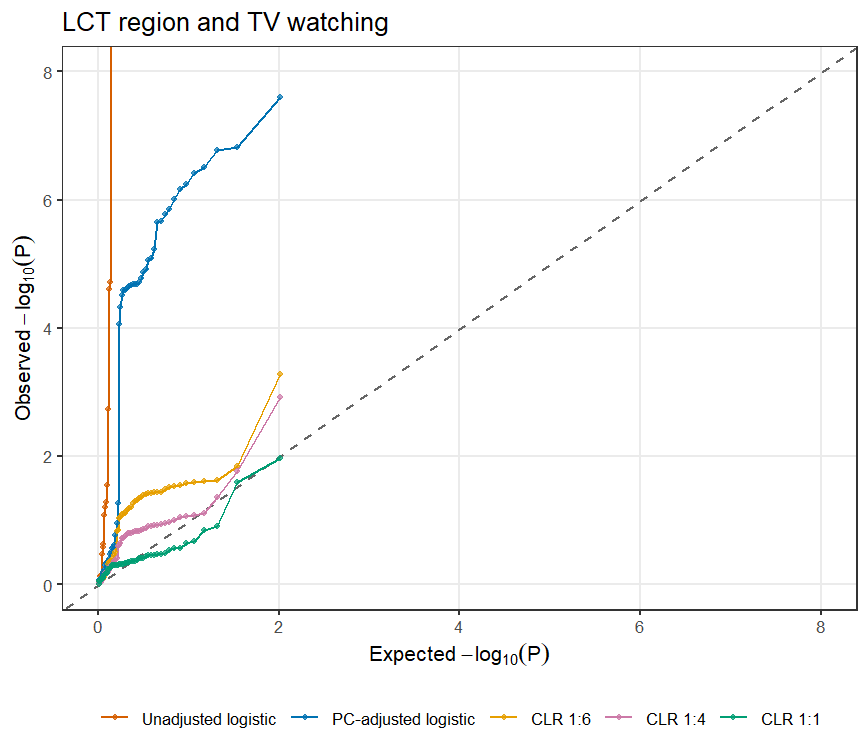

```r
qq <- qq_df(lct_tv, "LCT/TV")
ggplot(qq, aes(expected, observed, colour = method)) +
  geom_abline(slope = 1, intercept = 0, linetype = "dashed", colour = "grey40") +
  geom_line(linewidth = 0.5) +
  geom_point(size = 1.1, alpha = 0.7) +
  coord_cartesian(xlim = c(0, 8), ylim = c(0, 8)) +
  scale_colour_manual(values = method_cols) +
  labs(
    title = "LCT region and TV watching",
    x = expression(Expected ~ -log[10](P)),
    y = expression(Observed ~ -log[10](P)),
    colour = NULL
  ) +
  paper_theme
```

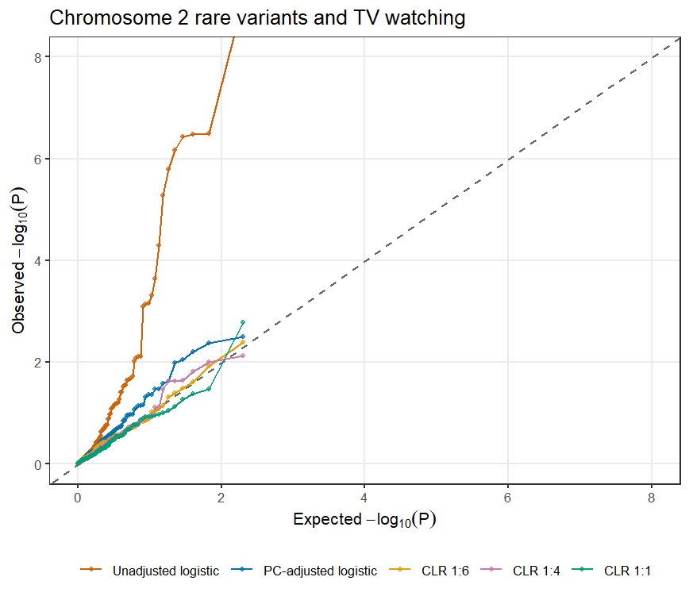

```r
qq2 <- qq_df(chr2, "chr2/TV")
ggplot(qq2, aes(expected, observed, colour = method)) +
  geom_abline(slope = 1, intercept = 0, linetype = "dashed", colour = "grey40") +
  geom_line(linewidth = 0.5) +
  geom_point(size = 1.1, alpha = 0.7) +
  coord_cartesian(xlim = c(0, 8), ylim = c(0, 8)) +
  scale_colour_manual(values = method_cols) +
  labs(
    title = "Chromosome 2 rare variants and TV watching",
    x = expression(Expected ~ -log[10](P)),
    y = expression(Observed ~ -log[10](P)),
    colour = NULL
  ) +
  paper_theme
```

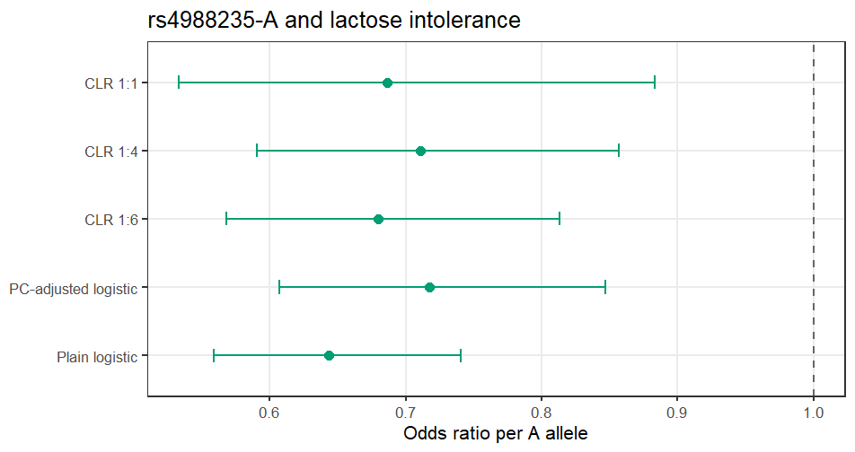

```r
rs4988235$Method <- factor(
  rs4988235$Method,
  levels = c("Plain logistic", "PC-adjusted logistic", "CLR 1:6", "CLR 1:4", "CLR 1:1")
)
ggplot(rs4988235, aes(OR, Method)) +
  geom_vline(xintercept = 1, linetype = "dashed", colour = "grey40") +
  geom_errorbar(aes(xmin = OR_lower, xmax = OR_upper), width = 0.2, orientation = "y", colour = "#009E73") +
  geom_point(colour = "#009E73", size = 2.2) +
  labs(
    title = "rs4988235-A and lactose intolerance",
    x = "Odds ratio per A allele",
    y = NULL
  ) +
  paper_theme +
  theme(legend.position = "none")
```

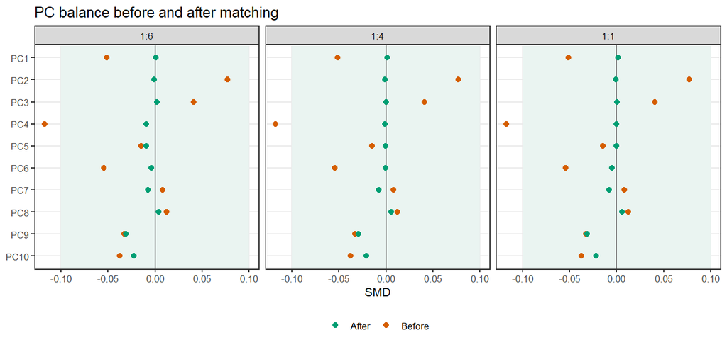

```r
pc_smd$pc_num <- as.integer(sub("PC", "", pc_smd$VARIABLE))
pc_smd$Ratio <- factor(pc_smd$Ratio, levels = c("1:6", "1:4", "1:1"))
pc_long <- rbind(
  data.frame(pc_smd[, c("Ratio", "VARIABLE", "pc_num")], SMD = pc_smd$PRE_SMD, Stage = "Before"),
  data.frame(pc_smd[, c("Ratio", "VARIABLE", "pc_num")], SMD = pc_smd$POST_SMD, Stage = "After")
)
ggplot(pc_long, aes(SMD, reorder(VARIABLE, -pc_num), colour = Stage)) +
  annotate("rect", xmin = -0.1, xmax = 0.1, ymin = -Inf, ymax = Inf, fill = "#EAF4F1", colour = NA) +
  geom_vline(xintercept = 0, colour = "grey50") +
  geom_point(size = 2) +
  facet_wrap(~Ratio) +
  scale_colour_manual(values = c(Before = "#D55E00", After = "#009E73")) +
  labs(title = "PC balance before and after matching", x = "SMD", y = NULL, colour = NULL) +
  paper_theme
```

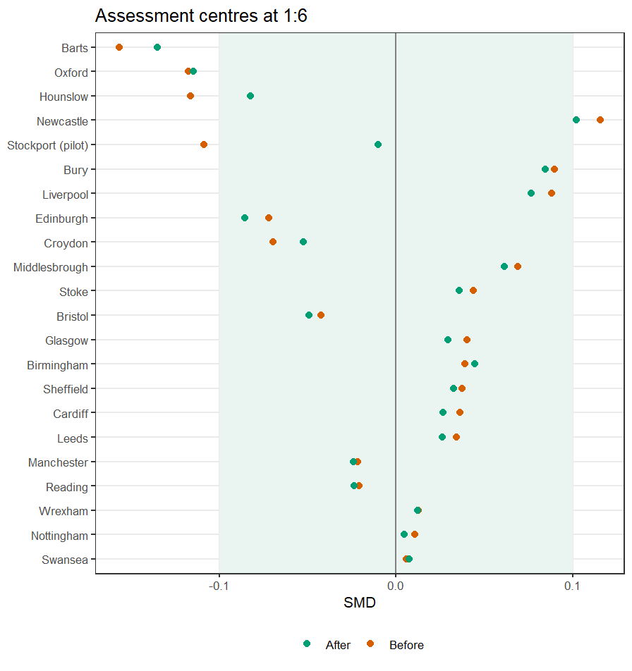

```r
c16 <- centres[centres$Ratio == "1:6", ]
c16 <- c16[order(abs(c16$PRE_SMD)), ]
c16$CENTRE <- factor(c16$CENTRE, levels = c16$CENTRE)
c_long <- rbind(
  data.frame(CENTRE = c16$CENTRE, SMD = c16$PRE_SMD, Stage = "Before"),
  data.frame(CENTRE = c16$CENTRE, SMD = c16$POST_SMD, Stage = "After")
)
ggplot(c_long, aes(SMD, CENTRE, colour = Stage)) +
  annotate("rect", xmin = -0.1, xmax = 0.1, ymin = -Inf, ymax = Inf, fill = "#EAF4F1", colour = NA) +
  geom_vline(xintercept = 0, colour = "grey50") +
  geom_point(size = 2) +
  scale_colour_manual(values = c(Before = "#D55E00", After = "#009E73")) +
  labs(title = "Assessment centres at 1:6", x = "SMD", y = NULL, colour = NULL) +
  paper_theme
```

# Simulation

The manuscript simulation used 1,000 replicates of 50,000 individuals, PC1 through PC5, and a common pool of 2,500 cases. Ancestry shifted both allele frequency and disease risk. Matched P values were score tests with the genotype coefficient set to zero.

```r
knitr::kable(
  sim_settings[sim_settings$parameter %in% c(
    "N", "n_iter", "n_pcs", "maf_A", "maf_B", "beta_positive",
    "max_matched_cases", "match_ratios", "matching_design"
  ), ],
  row.names = FALSE,
  caption = "Calibrated simulation settings."
)
```

*Calibrated simulation settings.*

| parameter | value |
| --- | --- |
| N | 50000 |
| n_iter | 1000 |
| maf_A | 0.01 |
| maf_B | 0.001 |
| beta_positive | 0.405465108108164 |
| n_pcs | 5 |
| match_ratios | 1,4,6 |
| max_matched_cases | 2500 |
| matching_design | real_aligned_pc_mahalanobis |

```r
ancestry <- rbinom(settings$N, size = 1L, prob = settings$prop_A)
pc_matrix <- sapply(seq_len(settings$n_pcs), function(index) {
  rnorm(
    settings$N,
    mean = settings$pc_separation[[index]] * ancestry,
    sd = settings$pc_sd
  )
})
maf <- ifelse(ancestry == 1L, settings$maf_A, settings$maf_B)
G <- rbinom(settings$N, size = 2L, prob = maf)
Y <- rbinom(
  settings$N,
  size = 1L,
  prob = plogis(settings$intercept + settings$ancestry_log_odds * ancestry + truth * G)
)
```

Matching used the same PC-only Mahalanobis rule as the UK Biobank analyses.

```r
match_object <- MatchIt::matchit(
  stats::reformulate(settings$pc_names, response = "Y"),
  data = data,
  method = "nearest",
  distance = "mahalanobis",
  estimand = "ATT",
  replace = FALSE,
  m.order = "farthest",
  ratio = ratio
)
```

```r
case_g <- genotype_matrix[, 1L]
mean_g0 <- rowMeans(genotype_matrix)
var_g0 <- rowMeans(genotype_matrix^2) - mean_g0^2
score0 <- sum(case_g - mean_g0)
information0 <- sum(var_g0)
p_value <- 2 * pnorm(-abs(score0 / sqrt(information0)))
```

```r
# Run from the repository root. This takes a long time.
# Rscript simulation/revised_oracle_matching_simulation.R --calibrated --n-pcs=5 --n-iter=1000 --N=50000 --max-matched-cases=2500
```

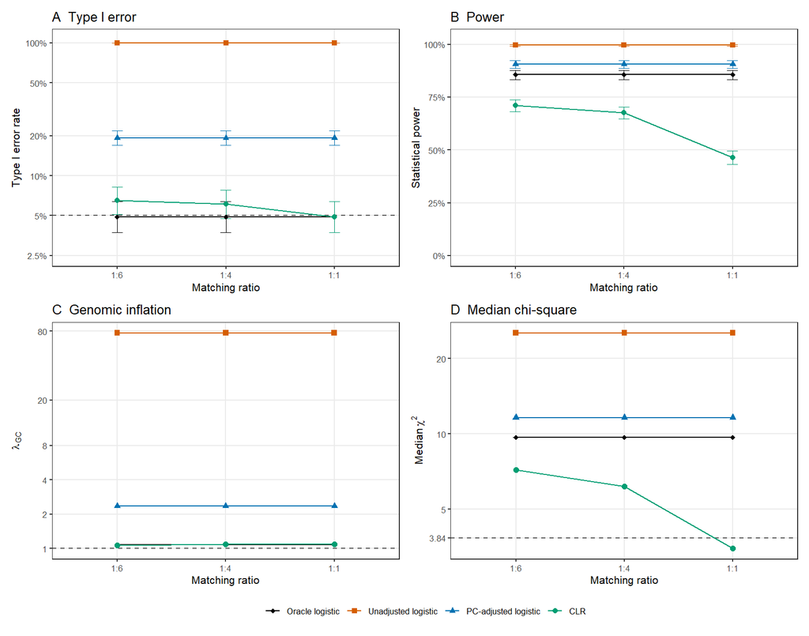

```r
suppressMessages(library(patchwork))
sim$ratio_label <- factor(as.character(sim$ratio_label), levels = c("1:6", "1:4", "1:1"))
sim$median_chisq <- sim$lambda_gc * qchisq(0.5, 1)
figure2_method_labels <- c(
  "Oracle GWAS" = "Oracle logistic",
  "Standard GWAS" = "Unadjusted logistic",
  "PC-adjusted GWAS" = "PC-adjusted logistic",
  "Matching + CLR" = "CLR"
)
sim$figure2_series <- factor(
  unname(figure2_method_labels[as.character(sim$method)]),
  levels = c("Oracle logistic", "Unadjusted logistic", "PC-adjusted logistic", "CLR")
)
figure2_colours <- c(
  "Oracle logistic" = "#000000",
  "Unadjusted logistic" = "#D55E00",
  "PC-adjusted logistic" = "#0072B2",
  "CLR" = "#009E73"
)
figure2_shapes <- c(
  "Oracle logistic" = 18,
  "Unadjusted logistic" = 15,
  "PC-adjusted logistic" = 17,
  "CLR" = 16
)
sim_neg <- sim[sim$scenario == "Negative control", ]
sim_pos <- sim[sim$scenario == "Positive control", ]
type1_plot <- ggplot(
  sim_neg,
  aes(ratio_label, rejection_rate, ymin = ci_lower, ymax = ci_upper, colour = figure2_series, shape = figure2_series)
) +
  geom_hline(yintercept = 0.05, linetype = "dashed", colour = "grey35") +
  geom_line(aes(group = figure2_series), linewidth = 0.55) +
  geom_errorbar(width = 0.1, linewidth = 0.45) +
  geom_point(size = 2.1) +
  scale_colour_manual(values = figure2_colours, drop = FALSE) +
  scale_shape_manual(values = figure2_shapes, drop = FALSE) +
  scale_y_log10(
    breaks = c(0.025, 0.05, 0.1, 0.2, 0.5, 1),
    labels = c("2.5%", "5%", "10%", "20%", "50%", "100%"),
    limits = c(0.025, 1.05)
  ) +
  labs(title = "A  Type I error", x = "Matching ratio", y = "Type I error rate", colour = NULL, shape = NULL) +
  paper_theme
power_plot <- ggplot(
  sim_pos,
  aes(ratio_label, rejection_rate, ymin = ci_lower, ymax = ci_upper, colour = figure2_series, shape = figure2_series)
) +
  geom_line(aes(group = figure2_series), linewidth = 0.55) +
  geom_errorbar(width = 0.1, linewidth = 0.45) +
  geom_point(size = 2.1) +
  scale_colour_manual(values = figure2_colours, drop = FALSE) +
  scale_shape_manual(values = figure2_shapes, drop = FALSE) +
  scale_y_continuous(labels = function(x) paste0(round(100 * x), "%"), limits = c(0, 1.02)) +
  labs(title = "B  Power", x = "Matching ratio", y = "Statistical power", colour = NULL, shape = NULL) +
  paper_theme
lambda_plot <- ggplot(sim_neg, aes(ratio_label, lambda_gc, colour = figure2_series, shape = figure2_series)) +
  geom_hline(yintercept = 1, linetype = "dashed", colour = "grey35") +
  geom_line(aes(group = figure2_series), linewidth = 0.55) +
  geom_point(size = 2.2) +
  scale_colour_manual(values = figure2_colours, drop = FALSE) +
  scale_shape_manual(values = figure2_shapes, drop = FALSE) +
  scale_y_log10(breaks = c(0.5, 1, 2, 4, 8, 20, 80), labels = c("0.5", "1", "2", "4", "8", "20", "80")) +
  labs(title = "C  Genomic inflation", x = "Matching ratio", y = expression(lambda[GC]), colour = NULL, shape = NULL) +
  paper_theme +
  guides(colour = "none", shape = "none")
positive_chisq_plot <- ggplot(sim_pos, aes(ratio_label, median_chisq, colour = figure2_series, shape = figure2_series)) +
  geom_hline(yintercept = qchisq(0.95, 1), linetype = "dashed", colour = "grey35") +
  geom_line(aes(group = figure2_series), linewidth = 0.55) +
  geom_point(size = 2.2) +
  scale_colour_manual(values = figure2_colours, drop = FALSE) +
  scale_shape_manual(values = figure2_shapes, drop = FALSE) +
  scale_y_log10(breaks = c(qchisq(0.95, 1), 5, 10, 20), labels = c("3.84", "5", "10", "20")) +
  labs(title = "D  Median chi-square", x = "Matching ratio", y = expression("Median " * chi^2), colour = NULL, shape = NULL) +
  paper_theme +
  guides(colour = "none", shape = "none")
(type1_plot | power_plot) / (lambda_plot | positive_chisq_plot) +
  plot_layout(guides = "collect") &
  theme(legend.position = "bottom")
```

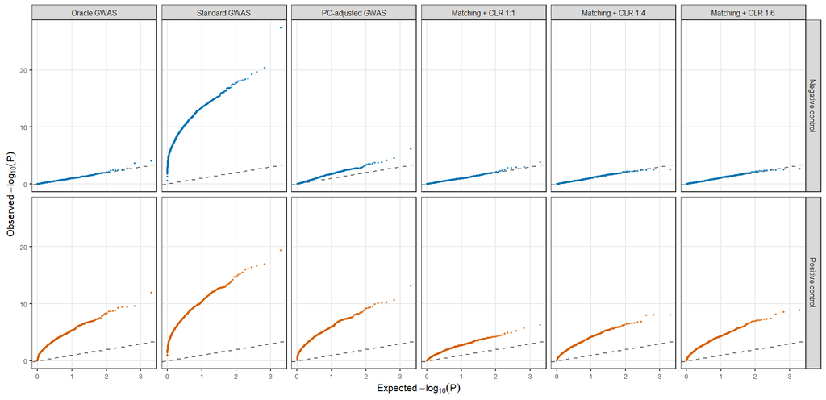

```r
sim_rep$method <- factor(
  sim_rep$method,
  levels = c("Oracle GWAS", "Standard GWAS", "PC-adjusted GWAS", "Matching + CLR")
)
qq_input <- sim_rep[
  sim_rep$method == "Matching + CLR" |
    (sim_rep$method != "Matching + CLR" & sim_rep$ratio == 1),
]
qq_input$panel <- ifelse(
  qq_input$method == "Matching + CLR",
  paste0("Matching + CLR 1:", qq_input$ratio),
  as.character(qq_input$method)
)
qq_input$panel <- factor(
  qq_input$panel,
  levels = c(
    "Oracle GWAS", "Standard GWAS", "PC-adjusted GWAS",
    "Matching + CLR 1:1", "Matching + CLR 1:4", "Matching + CLR 1:6"
  )
)
qq_groups <- split(qq_input, interaction(qq_input$scenario, qq_input$panel, drop = TRUE))
qq_sim <- do.call(rbind, lapply(qq_groups, function(d) {
  p <- d$p_value[is.finite(d$p_value) & d$p_value >= 0 & d$p_value <= 1]
  p <- pmax(p, .Machine$double.xmin)
  data.frame(
    scenario = as.character(d$scenario[[1L]]),
    panel = as.character(d$panel[[1L]]),
    expected = -log10(ppoints(length(p))),
    observed = -log10(sort(p)),
    stringsAsFactors = FALSE
  )
}))
qq_sim$scenario <- factor(qq_sim$scenario, levels = c("Negative control", "Positive control"))
qq_sim$panel <- factor(qq_sim$panel, levels = levels(qq_input$panel))
ggplot(qq_sim, aes(expected, observed, colour = scenario)) +
  geom_abline(slope = 1, intercept = 0, linetype = "dashed", colour = "grey40") +
  geom_point(size = 0.6, alpha = 0.7) +
  facet_grid(rows = vars(scenario), cols = vars(panel)) +
  scale_colour_manual(values = c("Negative control" = "#0072B2", "Positive control" = "#D55E00")) +
  labs(
    x = expression(Expected ~ -log[10](P)),
    y = expression(Observed ~ -log[10](P)),
    colour = NULL
  ) +
  paper_theme +
  theme(
    legend.position = "none",
    strip.text = element_text(size = 8),
    axis.text = element_text(size = 7)
  )
```